# Interview task - Sarah Habershon

2023-10-24

## Infrastructure deployment

Axis hierarchy: y, x, colour. The independent variable (cause) should go on the x-axis and the dependent variable (effect) should go on the y-axis.  
Chart selection: To show a relationship between two continuous variables, use a line or scatter chart.  
Scales: Prioritise the use of axes, because colour scales are less interpretable for the vision-impaired in the audience, and may be hard to read if printed in black and white.

In the original chart, the x axis is discrete; the real values are in the labels. The y axis represents a consistent value so it’s redundant - the colour scale is carrying the most salient information. I swapped the axes out so that the x axis now represents escalating target scenarios as a continuous variable, and the y axis carries the key variable - the percentage oversupply.

In adopting this approach I’ve assumed that the missing 60% value can be interpolated from the original analysis.

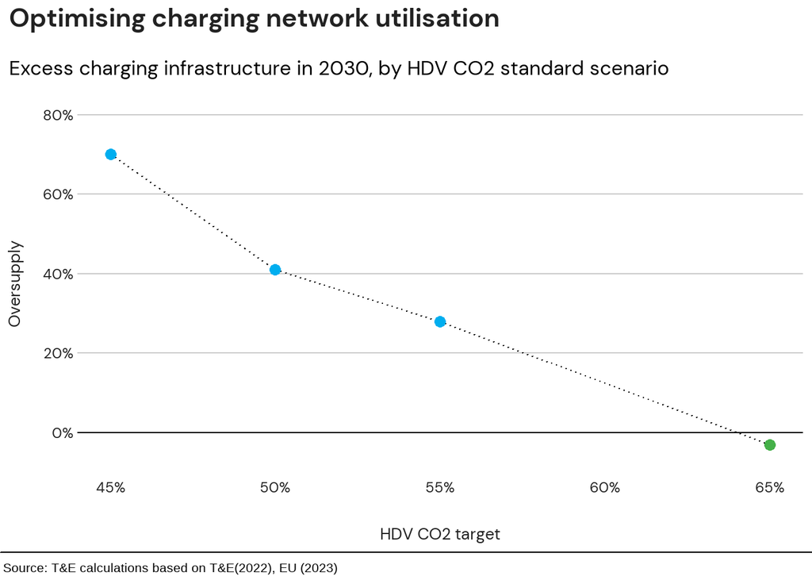

## Flights

Single responsibility: One story per chart  
Information hierarchy: The chart’s headings should describe the data being presented, including units and time period.

There are two stories in the original chart, one breaking down emissions by pricing regime, and the other comparing the prices airlines pay per tonne. I split them into two charts so that the carbon price would have its own axis. I moved the information describing the data (i.e. the sample range and the time period) into the headings. These headings aren’t as fun as the original, but I made them this way for a policy and media audience.

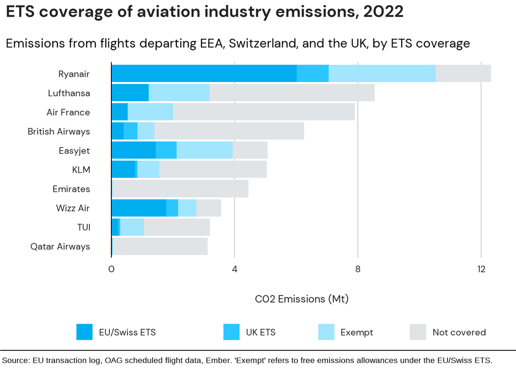

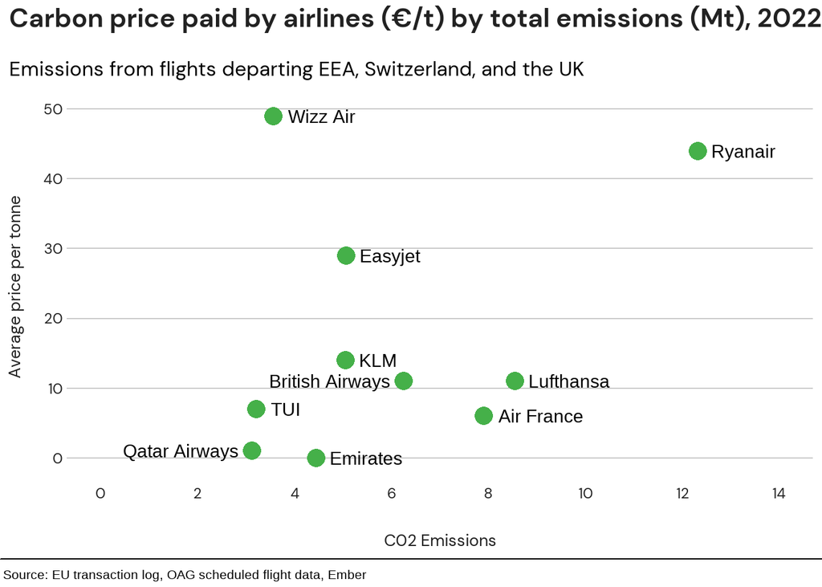

## Fuel cost

Information hierarchy: Key information, including units of measure, should go in the chart’s headings.  
Readability: Minimise labels to create more white space.

Previously, the fuel type labels differentiating the two charts were in the y-axis labels, I’ve moved those up into subheadings to make the distinction clear. The date axis doesn’t need to be so granular, since the purpose of the chart is to show a trend rather than highlight individual data points, so I limited x axis labels to the date range. I changed the highlighted countries to those with the minimum and maximum prices to bookend the spread, and added an EU-wide Mean.

An alternative option, if absolute price isn’t important to the story, would be to use a % change slope chart to emphasise the spread of impact.

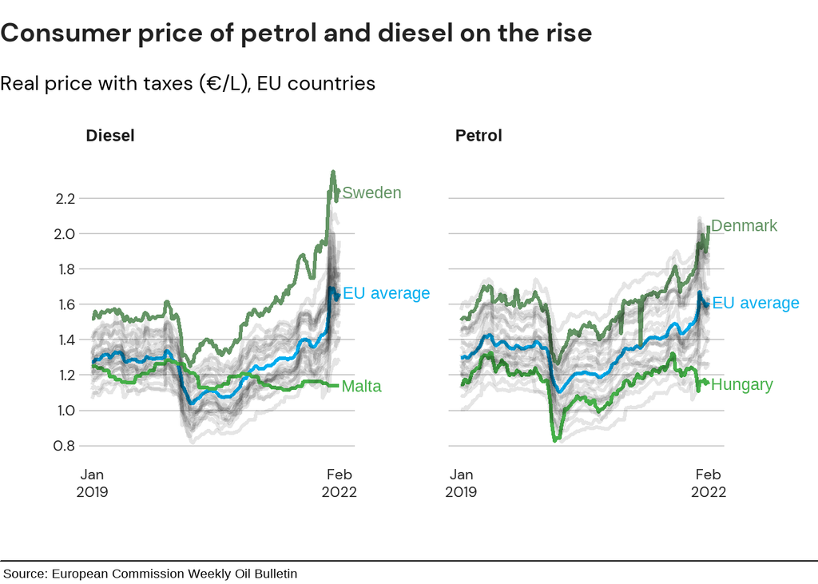